# Assignment_110825_NumPy_Pandas

## Section A: NumPy Assignment Questions

```python
from IPython.core.interactiveshell import InteractiveShell
InteractiveShell.ast_node_interactivity = 'all'
```

```python
import numpy as np
import os

import pandas as pd
```

#### Q1: Create a NumPy array with numbers from 1 to 20

- a) Print the array
- b) Reshape it into a 4x5 matrix
- c) Print only the even numbers from the array

```python
a = np.arange(1, 21)
print(a)
```

```
[ 1  2  3  4  5  6  7  8  9 10 11 12 13 14 15 16 17 18 19 20]
```

```python
b = a.reshape(4, 5)
print(b)
```

```
[[ 1  2  3  4  5]
 [ 6  7  8  9 10]
 [11 12 13 14 15]
 [16 17 18 19 20]]
```

```python
c = a[a % 2 == 0]
print(c)
```

```
[ 2  4  6  8 10 12 14 16 18 20]
```

#### Q2: Generate an array of 15 random integers between 10 and 50

- a) Find the mean, median, and standard deviation
- b) Sort the array in ascending order
- c) Replace all values greater than 30 with 30

```python
np.random.seed(9)
a = np.random.randint(10, 51, 15)
print(a)
```

```
[38 32 11 32 50 37 43 39 38 10 34 20 39 22 28]
```

```python
print(np.mean(a))
print(np.median(a))
print(np.std(a))
```

```
31.533333333333335
34.0
11.032477308182218
```

```python
b = np.sort(a)
print(b)
```

```
[10 11 20 22 28 32 32 34 37 38 38 39 39 43 50]
```

```python
c = np.where(a > 30, 30, a)
print(c)
```

```
[30 30 11 30 30 30 30 30 30 10 30 20 30 22 28]
```

#### Q3: Create a 1-D NumPy array and find the square root, cube, and natural log of each element

```python
a = np.array([1, 2, 3, 4, 5])

print(np.sqrt(a))
print(np.power(a, 3))
print(np.log(a))
```

```
[1.         1.41421356 1.73205081 2.         2.23606798]
[  1   8  27  64 125]
[0.         0.69314718 1.09861229 1.38629436 1.60943791]
```

#### Q4: Create a 5x5 identity matrix and change all diagonal elements to 7

```python
a = np.eye(5)
np.fill_diagonal(a, 7)
print(a)
```

```
[[7. 0. 0. 0. 0.]
 [0. 7. 0. 0. 0.]
 [0. 0. 7. 0. 0.]
 [0. 0. 0. 7. 0.]
 [0. 0. 0. 0. 7.]]
```

#### Q5: Create a NumPy array with 100 values from 0 to 1 using linspace

- a) Find the sum of all values less than 0.5
- b) Count how many values are greater than 0.8

```python
a = np.linspace(0, 1, 100)
```

```python
b = np.sum(a[a < 0.5])
c = np.sum(a > 0.8)

print(b)
print(c)
```

```
12.373737373737374
20
```

## Section B: Pandas Series Assignment Questions

#### Q6: Create a Pandas Series from a list of five fruit names

- a) Display the first 3 elements using head()
- b) Replace the 2nd fruit with "Pineapple"
- c) Check whether "Banana" is in the Series

```python
fruits_list = ["Apple", "Banana", "Cherry", "Mango", "Grapes"]
fruits = pd.Series(fruits_list)

fruits
```

```
0     Apple
1    Banana
2    Cherry
3     Mango
4    Grapes
dtype: object
```

```python
fruits.head(3)
```

```
0     Apple
1    Banana
2    Cherry
dtype: object
```

```python
fruits[1] = "Pineapple"
print(fruits)
```

```
0        Apple
1    Pineapple
2       Cherry
3        Mango
4       Grapes
dtype: object
```

```python
print("Banana" in fruits.values)
```

```
False
```

#### Q7: Create a Series from a dictionary

- a) Display the subject with the highest score
- b) Find the average score
- c) Add a new subject "Computer" with score 89

```python
scores_dict = {"Math": 87, "English": 78, "Science": 92, "History": 74, "Geography": 81}
scores = pd.Series(scores_dict)

scores
```

```
Math         87
English      78
Science      92
History      74
Geography    81
dtype: int64
```

```python
print(scores.idxmax())
```

```
Science
```

```python
print(scores.mean())
```

```
82.4
```

```python
scores["Computer"] = 89
print(scores)
```

```
Math         87
English      78
Science      92
History      74
Geography    81
Computer     89
dtype: int64
```

#### Q8: Create two Series of integers with overlapping values

- a) Find the union, intersection, and difference
- b) Compare both Series element-wise for equality

```python
a = pd.Series([1, 2, 3, 4, 5])
b = pd.Series([4, 5, 6, 7, 8])

a
b
```

```
0    1
1    2
2    3
3    4
4    5
dtype: int64
```

```
0    4
1    5
2    6
3    7
4    8
dtype: int64
```

```python
u = pd.Series(np.union1d(a, b))
i = pd.Series(np.intersect1d(a, b))
d = pd.Series(np.setdiff1d(a, b))

print(u)
print(i)
print(d)
```

```
0    1
1    2
2    3
3    4
4    5
5    6
6    7
7    8
dtype: int64
0    4
1    5
dtype: int64
0    1
1    2
2    3
dtype: int64
```

```python
c = a == b
print(c)
```

```
0    False
1    False
2    False
3    False
4    False
dtype: bool
```

#### Q9: Create a Series with custom indexes (days of the week)

- a) Access values for "Monday" and "Wednesday"
- b) Slice from "Tuesday" to "Friday"
- c) Change the value for "Sunday" to 100

```python
a = pd.Series([10, 20, 30, 40, 50, 60, 70],
                      index=["Monday", "Tuesday", "Wednesday", "Thursday", "Friday", "Saturday", "Sunday"])
```

```python
a
```

```
Monday       10
Tuesday      20
Wednesday    30
Thursday     40
Friday       50
Saturday     60
Sunday       70
dtype: int64
```

```python
print(a[["Monday", "Wednesday"]])
```

```
Monday       10
Wednesday    30
dtype: int64
```

```python
print(a["Tuesday":"Friday"])
```

```
Tuesday      20
Wednesday    30
Thursday     40
Friday       50
dtype: int64
```

```python
a["Sunday"] = 100
print(a)
```

```
Monday        10
Tuesday       20
Wednesday     30
Thursday      40
Friday        50
Saturday      60
Sunday       100
dtype: int64
```

#### Q10: Create a Series of 10 random numbers using np.random.randn()

- a) Calculate the mean and standard deviation
- b) Replace all negative values with 0
- c) Plot the Series (optional)

```python
np.random.seed(91)

a = pd.Series(np.random.randn(10))
a
```

```
0   -0.606121
1   -1.059940
2   -0.550920
3   -0.275686
4    1.222254
5   -0.905859
6    0.069352
7    2.178656
8    0.147317
9    0.517257
dtype: float64
```

```python
print(a.mean())
print(a.std())
```

```
0.07363098919703841
1.0094689049005177
```

```python
a[a < 0] = 0
print(a)
```

```
0    0.000000
1    0.000000
2    0.000000
3    0.000000
4    1.222254
5    0.000000
6    0.069352
7    2.178656
8    0.147317
9    0.517257
dtype: float64
```

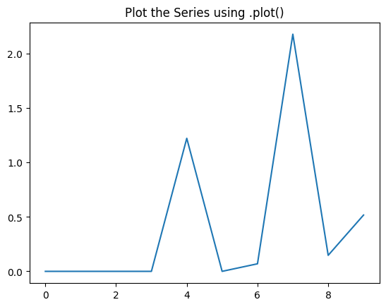

```python
a.plot(title="Plot the Series using .plot()")
```

### Bonus: Conceptual Questions

#### Q11: What is the difference between a NumPy array and a Pandas Series?

- NumPy arrays are homogeneous and optimized for numerical operations.
- Pandas Series are built on top of NumPy arrays but allow labeled indexing and can hold heterogeneous data.

#### Q12: Can a Pandas Series hold different data types? Justify with examples.

- Yes, a Series can hold mixed types, but it will upcast to a common type (usually `object`).

```python
a_list = [1, "apple", 3.14, True]
print(a_list)
```

```
[1, 'apple', 3.14, True]
```

```python
a_pandas = pd.Series(a_list)
print(a_pandas)
```

```
0        1
1    apple
2     3.14
3     True
dtype: object
```

#### Q13: How is broadcasting handled differently in NumPy vs Pandas?

- NumPy uses shape-based broadcasting.
- Pandas uses label-based alignment during operations, which can result in NaNs if labels don’t match.

#### Q14: What happens if you add two Series with different indexes? Give an example.

- Missing indexes will result in NaN.

```python
x = pd.Series([9, 20], index=["a", "b"])
y = pd.Series([18, 44], index=["b", "c"])
print(x + y)
```

```
a     NaN
b    38.0
c     NaN
dtype: float64
```